# Effects of modifying weights on epidemiologically relevant network properties

## Aims and objectives of this report

This report provides livestock movement data owners and data managers with information about how enhancing the privacy of these data affects epidemiologically relevant network properties. The aim is to facilitate finding an appropriate balance between privacy for the livestock industry, and utility for veterinary public health practitioners and modellers.

## Methods

### Initial data processing

Entries with weight (batch size) 0 or representing moves from a holding to itself (“loops”) were removed, as they were considered irrelevant for disease transmission and as potentially complicating the interpretability of analyses. Additionally, all repeated moves from and to the same holdings on the same day were aggregated into a single entry per day, with batch sizes summed up.

### Modification of weights for privacy enhancement

Movement weights were modified with the following functions:

- [`movenet::jitter_weights()`](https://digivet-consortium.github.io/movenet/reference/jitter_weights.html): This adds random noise between `-range` and `range` to movement weights, while ensuring that resulting weights remain greater than 0. `jitter_weights()` was applied with various `range` arguments: 5, 10, 50, 100 (until the order of magnitude of the mean weight in the data). To take into account the effects of random sampling, 3 simulations were run with each `range` argument.
- [`movenet::round_weights()`](https://digivet-consortium.github.io/movenet/reference/round_weights.html): This rounds movement weights to multiples of `unit`, and also sets `unit` as the minimum possible value for the resulting weights. `round_weights()` was applied with various `unit` arguments: 5, 10, 50, 100 (until the order of magnitude of the largest weight in the data).

### Creation of network representations

Static networks were created from true and privacy-enhanced datasets, for each subsequent 28 days in the data.

### Static network analyses (weighted)

## Static network analyses

### Global network properties

#### Average shortest path length

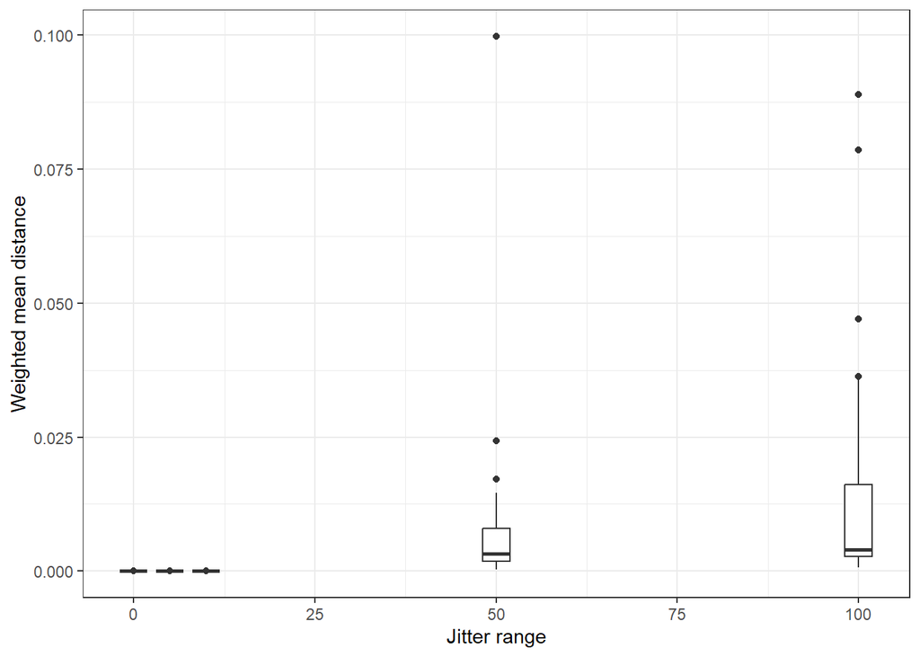

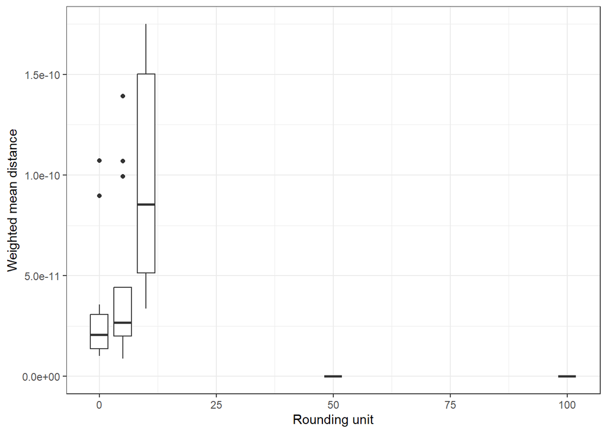

#### Strength assortativity

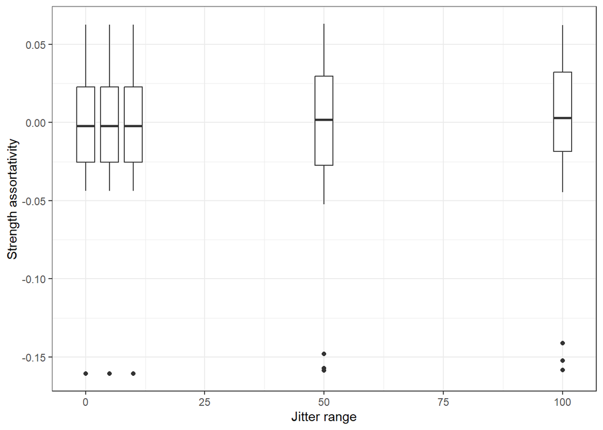

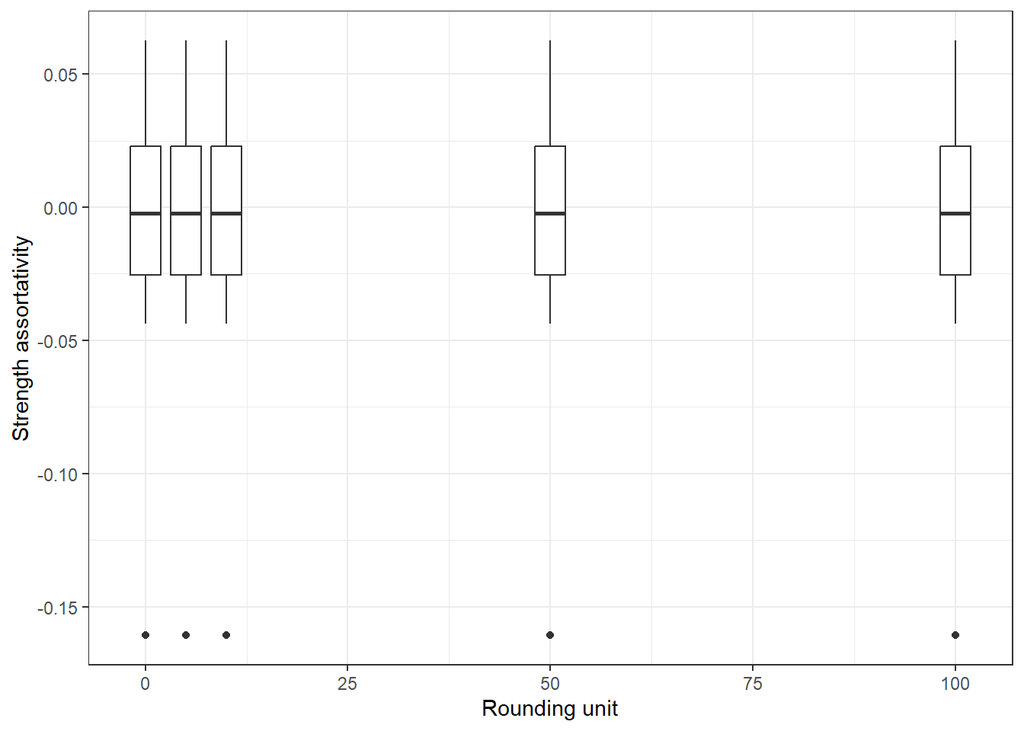

### Ranking of holdings according to local network properties

#### Strength centrality

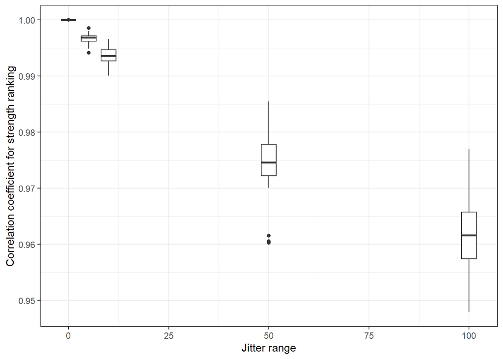

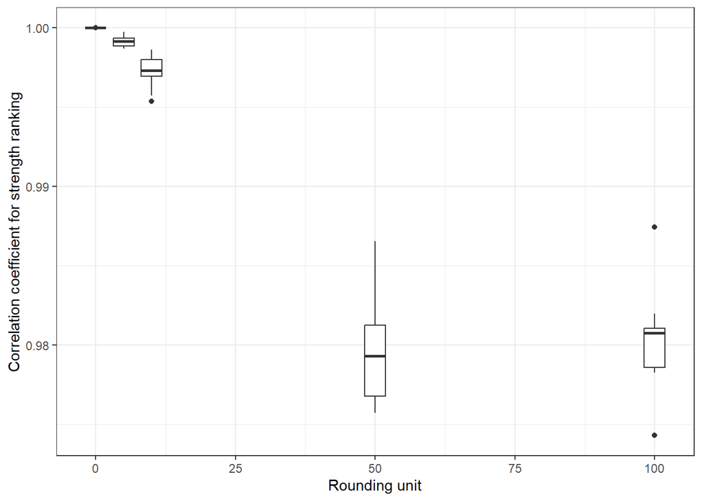

#### Betweenness centrality

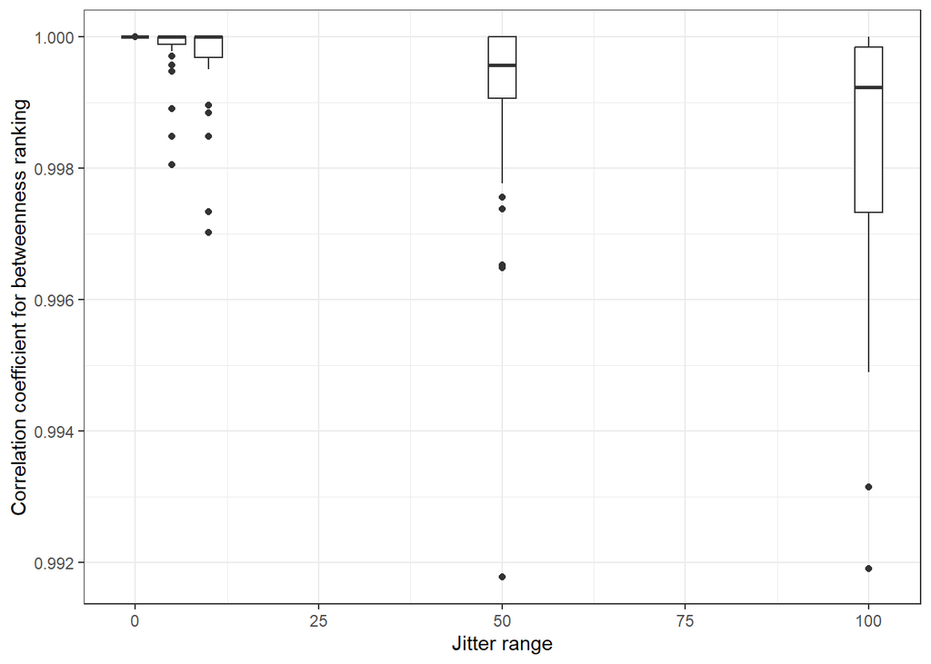

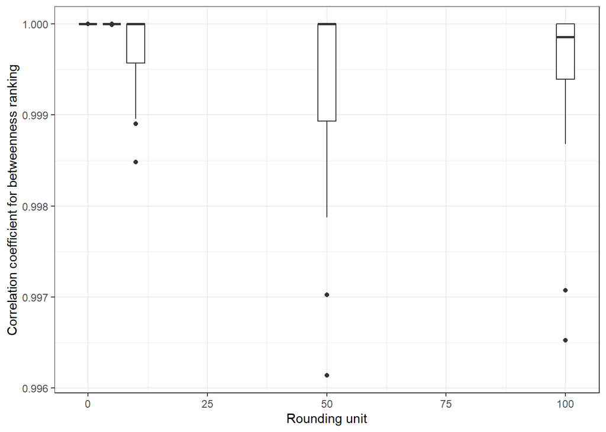

#### PageRank

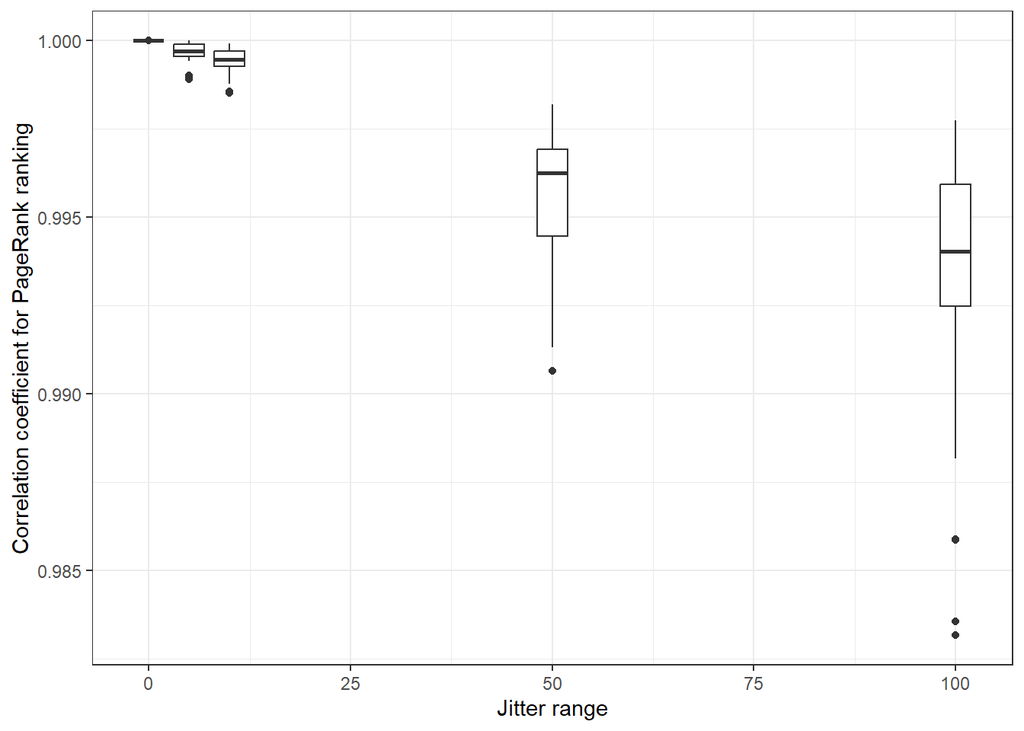

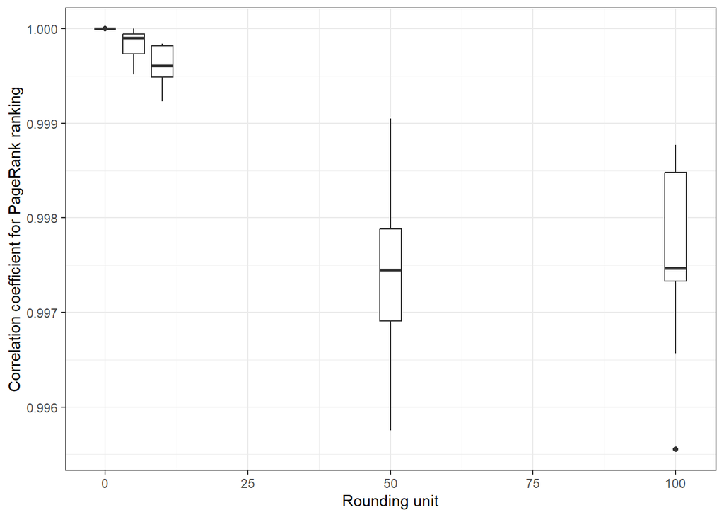